# DTSA 5509 Final Project

## Project Topic

In this notebook, we will create and examine models to detect breast cancer, using the Breast Cancer Wisconsin (Diagnostic) Data Set found here: https://www.kaggle.com/datasets/uciml/breast-cancer-wisconsin-data. Each of its 569 records provides a set of features computed from a digitized image of a fine needle aspirate of a breast mass, describing characteristics of the cell nuclei present in the image. Each record also includes that patient's diagnosis.

## Project Data

The Breast Cancer Wisconsin (Diagnostic) Data Set can be found here: https://www.kaggle.com/datasets/uciml/breast-cancer-wisconsin-data. It is 569 records x 33 columns (30 features, 1 y-value, 1 id, 1 unnamed NaN).

### Dataset columns:

(With descriptions when included by the source)

- id
- diagnosis - The diagnosis of breast tissues (M = malignant, B = benign)
- radius_mean - mean of distances from center to points on the perimeter
- texture_mean - standard deviation of gray-scale values
- perimeter_mean - mean size of the core tumor
- area_mean
- smoothness_mean - mean of local variation in radius lengths
- compactness_mean - mean of perimeter^2 / area - 1.0
- concavity_mean - mean of severity of concave portions of the contour
- concave points_mean - mean for number of concave portions of the contour
- symmetry_mean
- fractal_dimension_mean
- radius_se
- texture_se
- perimeter_se
- area_se
- smoothness_se
- compactness_se
- concavity_se
- concave points_se
- symmetry_se
- fractal_dimension_se
- radius_worst
- texture_worst
- perimeter_worst
- area_worst
- smoothness_worst
- compactness_worst
- concavity_worst
- concave points_worst
- symmetry_worst
- fractal_dimension_worst
- Unnamed: 32

After we import all of the packages we'll need for this notebook, we load the data.

```python
import pandas as pd
import numpy as np
import matplotlib.pyplot as plt
import seaborn as sns
import sklearn.model_selection
from sklearn.model_selection import train_test_split, cross_val_score, GridSearchCV
from sklearn.linear_model import LogisticRegression
from sklearn.metrics import precision_score, recall_score, accuracy_score, roc_curve, roc_auc_score
from sklearn.svm import LinearSVC, SVC
from sklearn.preprocessing import MinMaxScaler

# After downloading the CSV file from https://www.kaggle.com/datasets/uciml/breast-cancer-wisconsin-data
bcdf = pd.read_csv('Cancer_Data.csv')
bcdf.describe()
print("Dataset records x columns =", bcdf.shape)
```

```
Dataset records x columns = (569, 33)
```

## Data Cleaning

It's obvious that the id (presumably patient id number) and Unnamed (all NaN) columns are extraneous, so they are removed.

```python
bcdf.drop(['id'], axis = 1, inplace = True)
# Safely drop that last column with the unusual name
bcdf.drop(columns = bcdf.columns[-1], axis = 1, inplace = True)
print("Dataset records x columns =", bcdf.shape)
bcdf.describe()
```

```
Dataset records x columns = (569, 31)
```

|  | radius_mean | texture_mean | perimeter_mean | area_mean | smoothness_mean | compactness_mean | concavity_mean | concave points_mean | symmetry_mean | fractal_dimension_mean | ... | radius_worst | texture_worst | perimeter_worst | area_worst | smoothness_worst | compactness_worst | concavity_worst | concave points_worst | symmetry_worst | fractal_dimension_worst |
| --- | --- | --- | --- | --- | --- | --- | --- | --- | --- | --- | --- | --- | --- | --- | --- | --- | --- | --- | --- | --- | --- |
| count | 569.000000 | 569.000000 | 569.000000 | 569.000000 | 569.000000 | 569.000000 | 569.000000 | 569.000000 | 569.000000 | 569.000000 | ... | 569.000000 | 569.000000 | 569.000000 | 569.000000 | 569.000000 | 569.000000 | 569.000000 | 569.000000 | 569.000000 | 569.000000 |
| mean | 14.127292 | 19.289649 | 91.969033 | 654.889104 | 0.096360 | 0.104341 | 0.088799 | 0.048919 | 0.181162 | 0.062798 | ... | 16.269190 | 25.677223 | 107.261213 | 880.583128 | 0.132369 | 0.254265 | 0.272188 | 0.114606 | 0.290076 | 0.083946 |
| std | 3.524049 | 4.301036 | 24.298981 | 351.914129 | 0.014064 | 0.052813 | 0.079720 | 0.038803 | 0.027414 | 0.007060 | ... | 4.833242 | 6.146258 | 33.602542 | 569.356993 | 0.022832 | 0.157336 | 0.208624 | 0.065732 | 0.061867 | 0.018061 |
| min | 6.981000 | 9.710000 | 43.790000 | 143.500000 | 0.052630 | 0.019380 | 0.000000 | 0.000000 | 0.106000 | 0.049960 | ... | 7.930000 | 12.020000 | 50.410000 | 185.200000 | 0.071170 | 0.027290 | 0.000000 | 0.000000 | 0.156500 | 0.055040 |
| 25% | 11.700000 | 16.170000 | 75.170000 | 420.300000 | 0.086370 | 0.064920 | 0.029560 | 0.020310 | 0.161900 | 0.057700 | ... | 13.010000 | 21.080000 | 84.110000 | 515.300000 | 0.116600 | 0.147200 | 0.114500 | 0.064930 | 0.250400 | 0.071460 |
| 50% | 13.370000 | 18.840000 | 86.240000 | 551.100000 | 0.095870 | 0.092630 | 0.061540 | 0.033500 | 0.179200 | 0.061540 | ... | 14.970000 | 25.410000 | 97.660000 | 686.500000 | 0.131300 | 0.211900 | 0.226700 | 0.099930 | 0.282200 | 0.080040 |
| 75% | 15.780000 | 21.800000 | 104.100000 | 782.700000 | 0.105300 | 0.130400 | 0.130700 | 0.074000 | 0.195700 | 0.066120 | ... | 18.790000 | 29.720000 | 125.400000 | 1084.000000 | 0.146000 | 0.339100 | 0.382900 | 0.161400 | 0.317900 | 0.092080 |
| max | 28.110000 | 39.280000 | 188.500000 | 2501.000000 | 0.163400 | 0.345400 | 0.426800 | 0.201200 | 0.304000 | 0.097440 | ... | 36.040000 | 49.540000 | 251.200000 | 4254.000000 | 0.222600 | 1.058000 | 1.252000 | 0.291000 | 0.663800 | 0.207500 |

8 rows × 30 columns

The wide gap between the max and 75% values in many columns signify distant outliers. We will need to find a way to limit their effect.

But first, many of these factor columns have names that suggest correlation. Let's pull off and save the diagnosis column, then check the factors' correlation numbers.

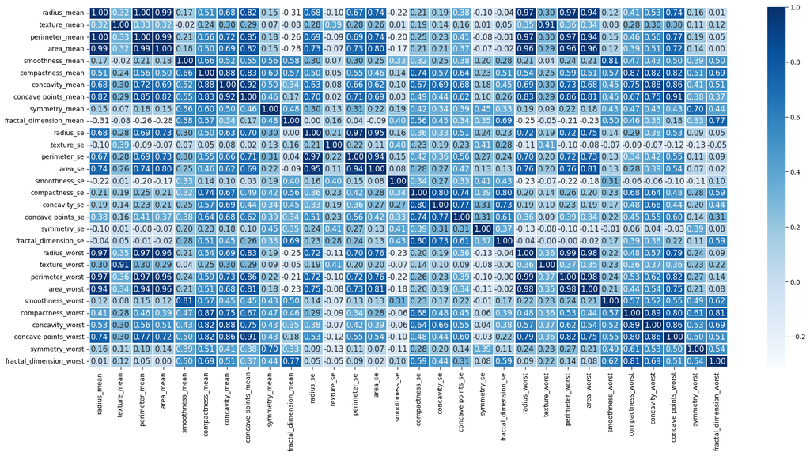

```python
diag = bcdf.diagnosis

bcdf.drop(['diagnosis'], axis = 1, inplace = True)

corrReport = bcdf.corr()
cmap = 'Blues'
# Make the grid cells wide enough to see the numbers
fig, ax = plt.subplots(figsize = (22, 10))
sns.heatmap(corrReport, cmap = cmap, annot = True, annot_kws={"size": 12}, linewidths=1, fmt='.2f')
plt.show()
```

There are a few strong correlations between factors. One set with mutual correlations of 0.94 or higher is

- radius_mean
- perimeter_mean
- area_mean
- radius_worst
- perimeter_worst
- area_worst

A smaller set of 0.94 or higher includes

- radius_se
- perimeter_se
- area_se

We will keep these in mind later to see whether we can drop some of those features to make a more flexible model.

### Outlier detection

Next, we will look for columns with values more than 2 * IQR from the 25% or 75% values.

```python
descFrame = bcdf.describe()

# describe() returns info for only numeric columns
featureNames = descFrame.columns
rowMin = descFrame.loc[["min"]]
row25 = descFrame.loc[["25%"]]
row75 = descFrame.loc[["75%"]]
rowMax = descFrame.loc[["max"]]
rowLength = descFrame.count(axis = 1)

for n in featureNames:
    val75 = row75[n].item()
    val25 = row25[n].item()
    IQR = val75 - val25
    minFence = val25 - (IQR * 2)
    if minFence < 0:
        minFence = 0
    maxFence = val75 + (IQR * 2)
    if rowMin[n].item() < minFence:
        print(n, "low outlier")
    if rowMax[n].item() > maxFence:
        print(n, "high outlier")
```

```
radius_mean high outlier
texture_mean high outlier
perimeter_mean high outlier
area_mean high outlier
smoothness_mean high outlier
compactness_mean high outlier
concavity_mean high outlier
concave points_mean high outlier
symmetry_mean high outlier
fractal_dimension_mean high outlier
radius_se high outlier
texture_se high outlier
perimeter_se high outlier
area_se high outlier
smoothness_se high outlier
compactness_se high outlier
concavity_se high outlier
concave points_se high outlier
symmetry_se high outlier
fractal_dimension_se high outlier
radius_worst high outlier
texture_worst high outlier
perimeter_worst high outlier
area_worst high outlier
smoothness_worst high outlier
compactness_worst high outlier
concavity_worst high outlier
symmetry_worst high outlier
fractal_dimension_worst high outlier
```

Although there are no low outliers, out of 30 factors, only `concave points_worst` did not have a high outlier. We will expect to limit outliers in every column.

## Exploratory Data Analysis

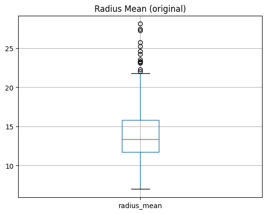

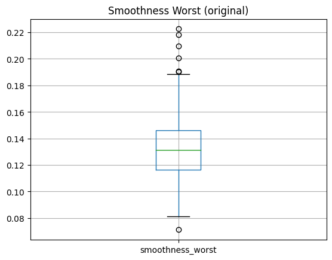

```python
beforeFig1 = bcdf.boxplot(column = "radius_mean")
beforeFig1.set_title("Radius Mean (original)")
plt.show()

beforeFig2 = bcdf.boxplot(column = "smoothness_worst")
beforeFig2.set_title("Smoothness Worst (original)")
plt.show()
```

We will deal with this by going back to the original data set and limiting its high values by substituting the "high fence" value (the 75% value + 2 times the IQR) for all outliers higher than that fence.

```python
# Same as above, now with corrective action
for n in featureNames:
    val75 = row75[n].item()
    val25 = row25[n].item()
    IQR = val75 - val25
    maxFence = val75 + (IQR * 2)

    # Now substitute the fences for the outliers
    bcdf[n] = np.where(bcdf[n] > maxFence, maxFence, bcdf[n])

bcdf.describe()
```

|  | radius_mean | texture_mean | perimeter_mean | area_mean | smoothness_mean | compactness_mean | concavity_mean | concave points_mean | symmetry_mean | fractal_dimension_mean | ... | radius_worst | texture_worst | perimeter_worst | area_worst | smoothness_worst | compactness_worst | concavity_worst | concave points_worst | symmetry_worst | fractal_dimension_worst |
| --- | --- | --- | --- | --- | --- | --- | --- | --- | --- | --- | --- | --- | --- | --- | --- | --- | --- | --- | --- | --- | --- |
| count | 569.000000 | 569.000000 | 569.000000 | 569.000000 | 569.000000 | 569.000000 | 569.000000 | 569.000000 | 569.000000 | 569.000000 | ... | 569.000000 | 569.000000 | 569.000000 | 569.000000 | 569.000000 | 569.000000 | 569.000000 | 569.000000 | 569.000000 | 569.000000 |
| mean | 14.100930 | 19.276520 | 91.791213 | 645.820562 | 0.096322 | 0.103891 | 0.088131 | 0.048848 | 0.181011 | 0.062688 | ... | 16.242476 | 25.672478 | 107.101951 | 862.123726 | 0.132305 | 0.252085 | 0.270733 | 0.114606 | 0.288659 | 0.083624 |
| std | 3.437955 | 4.250529 | 23.705406 | 320.188240 | 0.013910 | 0.051247 | 0.077331 | 0.038548 | 0.026875 | 0.006649 | ... | 4.744696 | 6.128812 | 33.052676 | 505.777677 | 0.022608 | 0.149188 | 0.203139 | 0.065732 | 0.056639 | 0.016751 |
| min | 6.981000 | 9.710000 | 43.790000 | 143.500000 | 0.052630 | 0.019380 | 0.000000 | 0.000000 | 0.106000 | 0.049960 | ... | 7.930000 | 12.020000 | 50.410000 | 185.200000 | 0.071170 | 0.027290 | 0.000000 | 0.000000 | 0.156500 | 0.055040 |
| 25% | 11.700000 | 16.170000 | 75.170000 | 420.300000 | 0.086370 | 0.064920 | 0.029560 | 0.020310 | 0.161900 | 0.057700 | ... | 13.010000 | 21.080000 | 84.110000 | 515.300000 | 0.116600 | 0.147200 | 0.114500 | 0.064930 | 0.250400 | 0.071460 |
| 50% | 13.370000 | 18.840000 | 86.240000 | 551.100000 | 0.095870 | 0.092630 | 0.061540 | 0.033500 | 0.179200 | 0.061540 | ... | 14.970000 | 25.410000 | 97.660000 | 686.500000 | 0.131300 | 0.211900 | 0.226700 | 0.099930 | 0.282200 | 0.080040 |
| 75% | 15.780000 | 21.800000 | 104.100000 | 782.700000 | 0.105300 | 0.130400 | 0.130700 | 0.074000 | 0.195700 | 0.066120 | ... | 18.790000 | 29.720000 | 125.400000 | 1084.000000 | 0.146000 | 0.339100 | 0.382900 | 0.161400 | 0.317900 | 0.092080 |
| max | 23.940000 | 33.060000 | 161.960000 | 1507.500000 | 0.143160 | 0.261360 | 0.332980 | 0.181380 | 0.263300 | 0.082960 | ... | 30.350000 | 47.000000 | 207.980000 | 2221.400000 | 0.204800 | 0.722900 | 0.919700 | 0.291000 | 0.452900 | 0.133320 |

8 rows × 30 columns

Here are boxplots of those same two columns, now with restrictions on outliers.

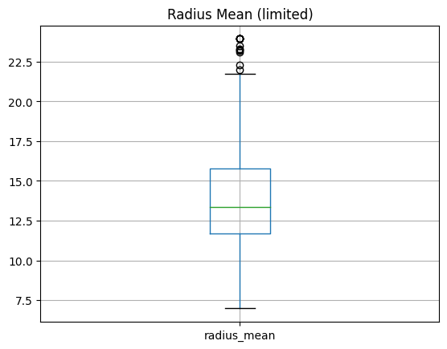

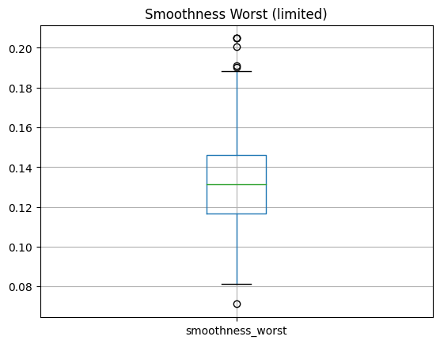

```python
afterFig1 = bcdf.boxplot(column = "radius_mean")
afterFig1.set_title('Radius Mean (limited)')
plt.show()

afterFig2 = bcdf.boxplot(column = "smoothness_worst")
afterFig2.set_title("Smoothness Worst (limited)")
plt.show()
```

Now that we've dealt with the outliers, it's time to split the diagnosis and features datasets into training and test sections. Let's keep 80% of the records for training.

```python
X_train, X_test, y_train, y_test = train_test_split(bcdf, diag, test_size = 0.2, random_state = 1)

print(X_train.shape, X_test.shape)
print(y_train.shape, y_test.shape)
```

```
(455, 30) (114, 30)
(455,) (114,)
```

## Models

### Logical regression

Now let's try out first model, logistic regression.

```
Logistic accurary is  0.956140350877193
Model precision is  0.935064935064935
Model recall is  1.0
```

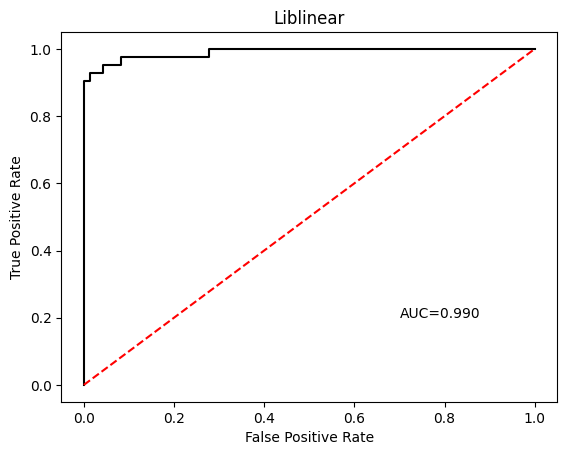

```python
logModel = LogisticRegression(solver = "liblinear", random_state = 1)
logModel.fit(X_train, y_train)

predArray = logModel.predict(X_test)
print("Logistic accurary is ", accuracy_score(y_test, predArray))
print("Model precision is ", precision_score(y_test, predArray, pos_label="B"))
print("Model recall is ", recall_score(y_test, predArray, pos_label="B"))

yPredProb = logModel.predict_proba(X_test)
fpr, tpr, th = roc_curve(y_test, yPredProb[:,1], pos_label="M")
auc = roc_auc_score(y_test, yPredProb[:,1])
plt.plot(fpr, tpr, 'k-')
plt.plot(np.arange(0, 1.1, 0.1), np.arange(0, 1.1, 0.1), 'r--')
plt.title('Liblinear');
plt.xlabel('False Positive Rate');
plt.ylabel('True Positive Rate');
plt.text(0.7, 0.2, 'AUC=' + "{:.3f}".format(auc));
```

Those are good numbers! How do they compare to using Newton-Cholesky?

```
Newton-Cholesky Logistic accurary is  0.9473684210526315
Newton-Cholesky Model precision is  0.9342105263157895
Newton-Cholesky Model recall is  0.9861111111111112
```

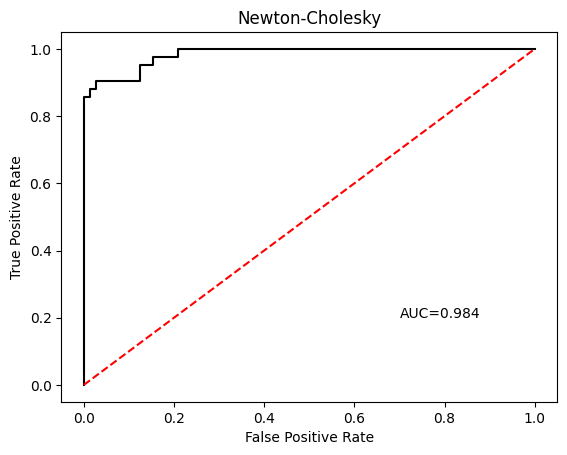

```python
ncModel = LogisticRegression(solver = "newton-cholesky", random_state = 1)
ncModel.fit(X_train, y_train)

ncPredArray = ncModel.predict(X_test)
print("Newton-Cholesky Logistic accurary is ", accuracy_score(y_test, ncPredArray))
print("Newton-Cholesky Model precision is ", precision_score(y_test, ncPredArray, pos_label="B"))
print("Newton-Cholesky Model recall is ", recall_score(y_test, ncPredArray, pos_label="B"))

yPredProb = ncModel.predict_proba(X_test)
fpr, tpr, th = roc_curve(y_test, yPredProb[:,1], pos_label="M")
auc = roc_auc_score(y_test, yPredProb[:,1])
plt.plot(fpr, tpr, 'k-')
plt.plot(np.arange(0, 1.1, 0.1), np.arange(0, 1.1, 0.1), 'r--')
plt.title('Newton-Cholesky');
plt.xlabel('False Positive Rate');
plt.ylabel('True Positive Rate');
plt.text(0.7, 0.2, 'AUC=' + "{:.3f}".format(auc));
```

Liblinear appears to be better than Newton-Cholesky for this dataset.

### LSVC

Let's try a Linear Support Vector Classification model for the data. After a first attempt, we see a warning that "Liblinear failed to converge". Online comments, especially at StackOverflow, suggest this warning should not be ignored, and is fixed by normalizing the features.

```
LSVC (hinge) accurary is  0.9736842105263158
LSVC (hinge) precision is  0.96
LSVC (hinge) recall is  1.0
```

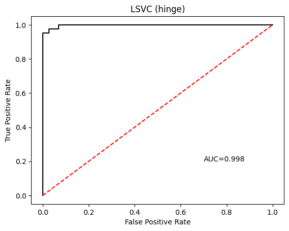

```python
# From https://scikit-learn.org/stable/modules/generated/sklearn.preprocessing.MinMaxScaler.html
scaler = MinMaxScaler()

# Transform the features into 0-1 normalization
X_train = scaler.fit_transform(X_train)
X_test = scaler.transform(X_test)

# MixMaxScaler.transform returns a numpy array
# Change it back to a Pandas dataframe and retrieve the column names
X_train = pd.DataFrame(X_train, columns = [featureNames])
X_test = pd.DataFrame(X_test, columns = [featureNames])

lsvcModel = LinearSVC(C = 1, loss = "hinge", random_state = 1)
lsvcModel = lsvcModel.fit(X_train, y_train)

lsvcPredArray = lsvcModel.predict(X_test)
print("LSVC (hinge) accurary is ", accuracy_score(y_test, lsvcPredArray))
print("LSVC (hinge) precision is ", precision_score(y_test, lsvcPredArray, pos_label="B"))
print("LSVC (hinge) recall is ", recall_score(y_test, lsvcPredArray, pos_label="B"))

yPredProb = lsvcModel._predict_proba_lr(X_test)
fpr, tpr, th = roc_curve(y_test, yPredProb[:,1], pos_label="M")
auc = roc_auc_score(y_test, yPredProb[:,1])
plt.plot(fpr, tpr, 'k-')
plt.plot(np.arange(0, 1.1, 0.1), np.arange(0, 1.1, 0.1), 'r--')
plt.title('LSVC (hinge)');
plt.xlabel('False Positive Rate');
plt.ylabel('True Positive Rate');
plt.text(0.7, 0.2, 'AUC=' + "{:.3f}".format(auc));
```

```
LSVC (squared_hinge) accurary is  0.9824561403508771
LSVC (squared_hinge) precision is  0.972972972972973
LSVC (squared_hinge) recall is  1.0
```

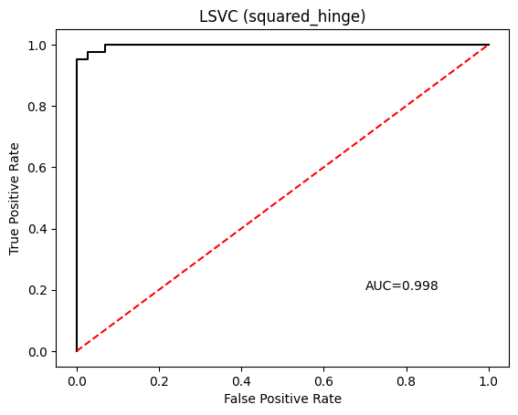

```python
lsvc2Model = LinearSVC(C = 1, loss = "squared_hinge", random_state = 1)
lsvc2Model = lsvc2Model.fit(X_train, y_train)

lsvc2PredArray = lsvc2Model.predict(X_test)
print("LSVC (squared_hinge) accurary is ", accuracy_score(y_test, lsvc2PredArray))
print("LSVC (squared_hinge) precision is ", precision_score(y_test, lsvc2PredArray, pos_label="B"))
print("LSVC (squared_hinge) recall is ", recall_score(y_test, lsvc2PredArray, pos_label="B"))

yPredProb2 = lsvc2Model._predict_proba_lr(X_test)
fpr, tpr, th = roc_curve(y_test, yPredProb2[:,1], pos_label="M")
auc = roc_auc_score(y_test, yPredProb2[:,1])
plt.plot(fpr, tpr, 'k-')
plt.plot(np.arange(0, 1.1, 0.1), np.arange(0, 1.1, 0.1), 'r--')
plt.title('LSVC (squared_hinge)');
plt.xlabel('False Positive Rate');
plt.ylabel('True Positive Rate');
plt.text(0.7, 0.2, 'AUC=' + "{:.3f}".format(auc));
```

Except for recall, which was already perfect, changing to the LSVC model improved the results. Within LSVC, squared_hinge produced slightly better accuracy and precision, though not enough to make a difference in the AUC chart.

### Non-linear SVC

Let's try a third model against this dataset. After checking SVC with default values, we'll tweak the C and gamma settings to see if we can find one that produces better accuracy than Linear SVC.

```python
nlsvm = None

nlsvm = SVC(gamma = 1) # default kernel is rbf, default C = 1
scores = cross_val_score(nlsvm, X_train, y_train)
print("1 cross-val mean-accuracy: ", np.mean(scores))

grid = None
thisSVM = SVC() # with defaults
valuesC = []
valuesGamma = []
for i in range(-5, 6):
    newValue = 2**i
    valuesC.append(newValue)
    valuesGamma.append(newValue)
cgGrid = {"C": valuesC, "gamma": valuesGamma}

searchedGrid = GridSearchCV(thisSVM, cgGrid, cv = 3)
searchedGrid.fit(X_train, y_train)

print("Best mean_accuracy = ", searchedGrid.best_score_)
print("Using the parameters ", searchedGrid.best_params_)

grid = searchedGrid
```

```
1 cross-val mean-accuracy:  0.9692307692307691
Best mean_accuracy =  0.9692546764261648
Using the parameters  {'C': 16, 'gamma': 0.0625}
```

### Tweaking the best of three models

The best model so far is the squared_hinge version of LSVC. Let's see whether there is another value of C that will produce better accuracy.

```python
bestC = 1
bestAccuracy = 0

i = 0.1
while i < 11:
    tempLSVC = LinearSVC(C = i, loss = "squared_hinge", random_state = 1)
    tempLSVC = tempLSVC.fit(X_train, y_train)
    tempPredArray = tempLSVC.predict(X_test)
    tempAccuracy = accuracy_score(y_test, tempPredArray)
    if tempAccuracy > bestAccuracy:
        bestAccuracy = tempAccuracy
        bestC = i
    i = i + 0.1

print("For accuracy, the best C is ", bestC)
print("which produced an accuracy of ", bestAccuracy)
print("But from there, accuracy is identical.")
print("For example, the last C tested was 11")
print("which also produced an accuracy of ", tempAccuracy)
```

```
For accuracy, the best C is  0.4
which produced an accuracy of  0.9824561403508771
But from there, accuracy is identical.
For example, the last C tested was 11
which also produced an accuracy of  0.9824561403508771
```

The answer is No. Within a wide range, different values of C do not change the model's accuracy score.

## Discussion

Let's go back to an idea from the start of this process. With so many strongly correlated features, will the best model produce the same or better results after dropping duplicative features?

```python
# In the first set of correlated features, retain area_mean
bcdf.drop(['radius_mean'], axis = 1, inplace = True)
bcdf.drop(['perimeter_mean'], axis = 1, inplace = True)
bcdf.drop(['radius_worst'], axis = 1, inplace = True)
bcdf.drop(['perimeter_worst'], axis = 1, inplace = True)
bcdf.drop(['area_worst'], axis = 1, inplace = True)

# In the second set of correlated features, retain area_se
bcdf.drop(['radius_se'], axis = 1, inplace = True)
bcdf.drop(['perimeter_se'], axis = 1, inplace = True)

# Now split them again and check the number of features
X_train, X_test, y_train, y_test = train_test_split(bcdf, diag, test_size = 0.2, random_state = 1)

print(X_train.shape, X_test.shape)
print(y_train.shape, y_test.shape)
```

```
(455, 23) (114, 23)
(455,) (114,)
```

```python
# Try the best model now against the 23-feature reduced data set
lsvc23Model = LinearSVC(C = 1, loss = "squared_hinge", random_state = 1)
lsvc23Model = lsvc23Model.fit(X_train, y_train)

lsvc23PredArray = lsvc23Model.predict(X_test)
print("New LSVC (squared_hinge) accurary is ", accuracy_score(y_test, lsvc2PredArray))
print("New LSVC (squared_hinge) precision is ", precision_score(y_test, lsvc2PredArray, pos_label="B"))
print("New LSVC (squared_hinge) recall is ", recall_score(y_test, lsvc2PredArray, pos_label="B"))
```

```
New LSVC (squared_hinge) accurary is  0.9824561403508771
New LSVC (squared_hinge) precision is  0.972972972972973
New LSVC (squared_hinge) recall is  1.0
```

## Conclusion

It is possible to create numerous models to effectively predict breast cancer diagnoses based on the Breast Cancer Wisconsin (Diagnostic) Data Set. Although all of the examined models are accurate, some models are more accurate than others. In particular, the Squared Hinge version of the Linear Support Vector Classification produced the most accurate predictions of the test data. Almost any value of the C hyperparameter allows this result.